# BIOS 635: Logistic Regression

Kevin Donovan

1/28/2021

# Review

- Homework 2 due on 2/4 at 11PM through GitHub Classroom
- Article Evaluation 1 assigned, due on 2/9 through GitHub Classroom
- Last lecture: discussed k-nearest neighbor and linear regression

# Classification

Let response $Y \in \{0,1\}$

**Goal**: Predict $Y$ using features $X$

**What to model?**:

Let $p_k(x)=\text{Pr}(Y=k|X=x)$, $k=0,1$

Denoted as the **conditional class probabilities** at $x$

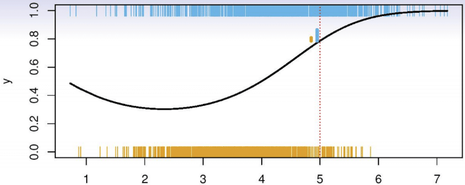

# Example: Heart Disease

**Goal**: Predict diagnosis of heart disease in patients

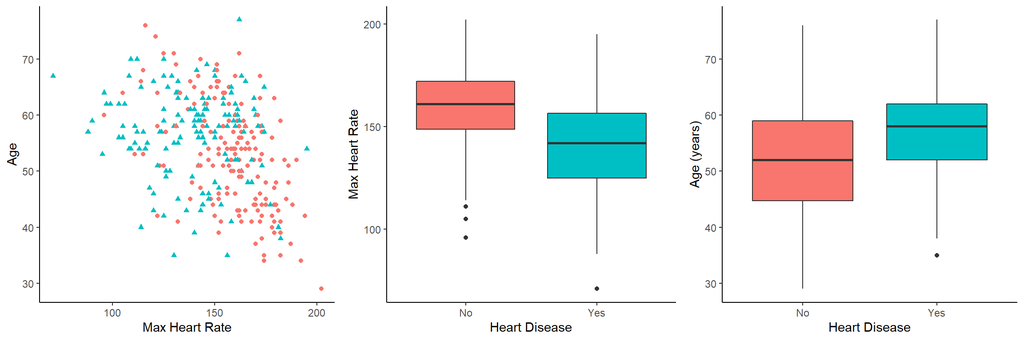

# Classification: Regression

**Recall**: Linear regression model

$Y=\beta_0+\beta_1X_1+\ldots+\beta_pX_p+\epsilon$

$E(Y|X)=\beta_0+\beta_1X_1+\ldots+\beta_pX_p$ as $\text{E}(\epsilon|X)=\text{E}(\epsilon)=0$

For binary $Y$, $\text{E}(Y|X)=\text{Pr}(Y=1|X)$

$\text{Pr}(Y=1|X)=\beta_0+\beta_1X_1+\ldots+\beta_pX_p$

Denoted *linear probability model*

**Limitation**: $0 \leq\text{Pr}(Y=1|X) \leq 1$ but linear function not constrained

# Classification: Regression

**Consider**:

Model probability of heart disease as function of max heart rate

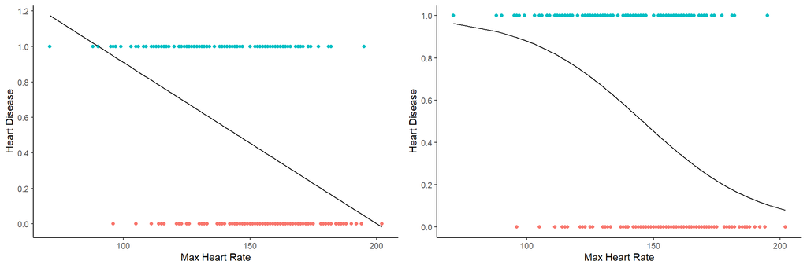

# Logistic Regression

**Model**: Single Feature $X$

$\text{logit}[p(Y=1|X)]=\beta_0+\beta_1X$

where $\text{logit}(p)=\text{ln}(\frac{p}{1-p})=\text{log}( \text{odds}[p(Y=1|X)])$

**In terms of conditional probability**:

$p(Y=1|X)=\frac{e^{\beta_0+\beta_1X}}{1+e^{\beta_0+\beta_1X}}$

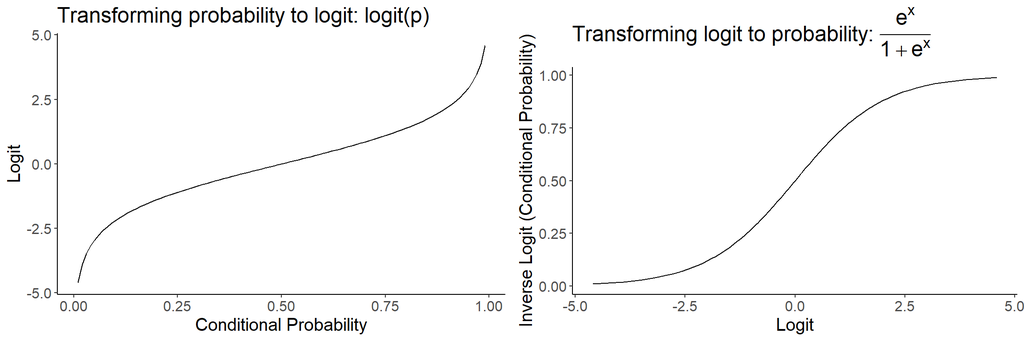

# Logistic Regression

**Estimation**: Maximum Likelihood

Specify distribution for $Y|X$ as $Y$ is **binary**

Observation $i$’s distribution: $f(y_i|x_i)=p(x_i)^{y_i}[1-p(x_i)]^{1-y_i}$

implies $f(1|x_i)=p(x_i)$ and $f(0|x_i)=1-p(x_i)$

where $p(x_i)=\text{Pr}(Y_i=1|X_i)$

# Maximum Likelihood

For $n$ independent observations, have joint distribution of sample:

$$\begin{align}
f(y|x)&=\prod_{i=1}^{n=1} p(x_i)^{y_i}[1-p(x_i)]^{1-y_i}\\
\text{log}(f)&=\sum_{i=1}^{n}y_i\text{log}[p(x_i)]+(1-y_i)\text{log}[1-p(x_i)]\\
&=\sum_{i=1}^{n_1}\text{log}[p(x_i)]+\sum_{j=1}^{n_0}\text{log}[1-p(x_i)]\\
&\text{where }n_1=\sum_{i=1}^n(y_i) \text{ and } n_0=n-n_1
\end{align}$$

modeling $\text{logit}[p(Y=1|X)]=\beta_0+\beta_1X_1+\ldots+\beta_pX_p$

# Maximum Likelihood Example

**Intuition**:

Find estimates of $\beta$ which best match with observed data, assuming data generated from specified likelihood

Fitting in `R`: `glm` function

```r
glm_fit <-
  glm(heart_disease~MAX_Heart_Rate+Age,
              family=binomial(),
             data=heart_data)

# Raw output
summary(glm_fit)
```

```
##
## Call:
## glm(formula = heart_disease ~ MAX_Heart_Rate + Age, family = binomial(),
##     data = heart_data)
##
## Deviance Residuals:
##     Min       1Q   Median       3Q      Max
## -2.1108  -0.9418  -0.5842   1.0657   2.0774
##
## Coefficients:
##                 Estimate Std. Error z value Pr(>|z|)
## (Intercept)     4.839597   1.498563   3.229  0.00124 **
## MAX_Heart_Rate -0.040711   0.006808  -5.980 2.24e-09 ***
## Age             0.019706   0.015339   1.285  0.19889
## ---
## Signif. codes:  0 '***' 0.001 '**' 0.01 '*' 0.05 '.' 0.1 ' ' 1
##
## (Dispersion parameter for binomial family taken to be 1)
##
##     Null deviance: 417.98  on 302  degrees of freedom
## Residual deviance: 359.24  on 300  degrees of freedom
## AIC: 365.24
##
## Number of Fisher Scoring iterations: 3
```

```r
# Format output
tidy(glm_fit) %>%
  mutate(p.value=ifelse(p.value<0.005, "<0.005",
                        as.character(round(p.value, 3))),
         term=fct_recode(factor(term),
                         "Intercept"="(Intercept)",
                         "Max Heart Rate"=
                         "MAX_Heart_Rate")) %>%
  flextable() %>%
  set_header_labels("term"="Variable",
                    "estimate"="Estimate",
                    "std.error"="Std. Error",
                    "statistic"="Z Statistic",
                    "p.value"="P-value") %>%
  autofit()
```

| Variable | Estimate | Std. Error | Z Statistic | P-value |
| --- | --- | --- | --- | --- |
| Intercept | 4.840 | 1.4986 | 3.2 | <0.005 |
| Max Heart Rate | -0.041 | 0.0068 | -6.0 | <0.005 |
| Age | 0.020 | 0.0153 | 1.3 | 0.199 |

# Generalized Linear Models

Logistic regression models are an example of a *generalized linear model* (GLM)

**GLM**: Extension of standard linear model to handle general distributions

Examples:

- Normally distributed residuals (linear regression)
- Binary outcomes (logisitic regression)
- Categorical outcomes (multinomial logisitc regression)
- Count outcomes Poisson regression)
- Rates (beta regression)

# Generalized Linear Models

**Structure of model**:

1. Choose conditional distribution $f(y|x)$
- Linear regression: $f(y|x)\sim \text{Normal}(\mu_{y|x}, \sigma^2)$
  - $\mu_{y|x} = \text{E}(Y|X); \sigma^2=\text{Var}(Y|X)=\text{Var}(\epsilon)$
- Logistic regression: $f(y|x)\sim \text{Binomial}[p(x)]$
  - $p(x) = \mu_{y|x} = \text{Pr}(Y=1|X)$

# Generalized Linear Models

2. Choose *link function* $g(\mu_{y|x})=\beta_0+\beta_1X_1+\ldots+\beta_pX_p$
- Linear regression: $g(\mu_{y|x})=\mu_{y|x}$
- Logistic regression $g(\mu_{y|x})=\log(\frac{\mu_{y|x}}{1-\mu_{y|x}})$
- **Idea**: $g(\mu_{y|x}):\mathcal{X}_\mu \rightarrow (-\infty, \infty)$
3. Construct likelihood and fit
- Assuming independent observations:
  - $f(y|x)=\prod_{i=1}^{n} f(y_i|x_i)$

# Logistic Regression

Let’s go back to heart disease example:

| Variable | Estimate | Std. Error | Z Statistic | P-value |
| --- | --- | --- | --- | --- |
| Intercept | 4.840 | 1.4986 | 3.2 | <0.005 |
| Max Heart Rate | -0.041 | 0.0068 | -6.0 | <0.005 |
| Age | 0.020 | 0.0153 | 1.3 | 0.199 |

**Estimated model**: $\hat{\text{Pr}}[Y=1|HeartRate, Age]=\frac{e^{4.84-0.041HeartRate+0.02Age}}{1+e^{4.84-0.041HeartRate+0.02Age}}$

**Interpretation**:

1. $\hat{\beta_0}=4.840$
- $\hat{\text{Pr}}[Y=1|HeartRate=0, Age=0]=\frac{e^{4.84}}{1+e^{4.84}}$
2. $\hat{\beta_1}=-0.041$
- $\rightarrow$ Probability of heart disease **decreases** as `max heart rate` **increases** (holding `age` fixed)
3. $\hat{\beta_1}=0.02$
- $\rightarrow$ Probability of heart disease **increase** as `age` **increases** (holding `max heart rate` fixed)
  - P-value = 0.2 $\rightarrow$ `age` may not be useful predictor

# Logistic Regression

**Intercept**:

- `heart rate` = 0 and/or `age` = 0 doesn’t make sense

**Solution**: center at means

- `heart rate` - $\mu$ = 0 $\rightarrow$ `heart rate` = $\mu$

| Variable | Estimate | Std. Error | Z Statistic | P-value |
| --- | --- | --- | --- | --- |
| Intercept | -0.178 | 0.1276 | -1.4 | 0.162 |
| Max Heart Rate centered | -0.041 | 0.0068 | -6.0 | <0.005 |
| Age (years) centered | 0.020 | 0.0153 | 1.3 | 0.199 |

**Interpretation**:

1. $\hat{\beta_0} = -0.18$

$$\hat{\text{Pr}}[Y=1|HeartRate=0, Age=0]=\frac{e^{-0.18}}{1+e^{-0.18}}$$

Slopes $\hat{\beta_1}, \hat{\beta_2}$ not changed

# Logistic Regression

Model-based estimated probabilities (non-centered):

For patient with `heart rate`=150 and age=65 years

$$\hat{\text{Pr}}[Y=1|HeartRate=150, Age=65]=\frac{e^{4.84-0.041*150+0.02*65}}{1+e^{4.84-0.041*150+0.02*60}}=0.4975$$

Based on $\hat{\text{Pr}}[Y=1|HeartRate, Age]$ can create predicted response $\hat{Y}$ by thresholding

# Logistic Regression: Confounding

**Example**: Credit Card Default Rate

- Consider predicting if a person defaults on their loan based on
  - Student Status (Student or Not Student):

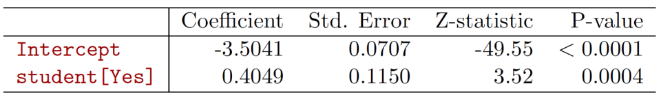

- Now consider adding features: `credit balance` and `income`

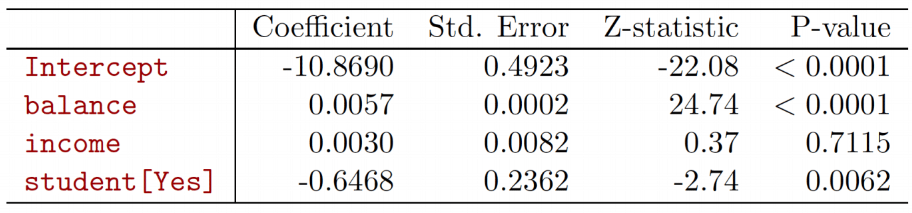

- Why did `student`’s coefficient change so much? **Confounding**

# Logistic Regression: Confounding

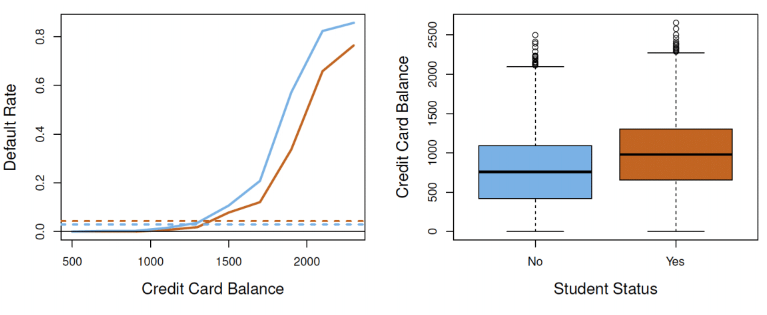

- Being a student $\rightarrow$ higher balance (more loans)
  - $\rightarrow$ higher marginal default rate vs non-students
  - But is it the higher balance or simply them being students leading to defaulting more often?
  - Need to compare students and non-students **controlling** for balance to answer this
  - Can be done using regression

# Logistic Regression: Prediction

**Example**: Model probability of heart disease as function of many features

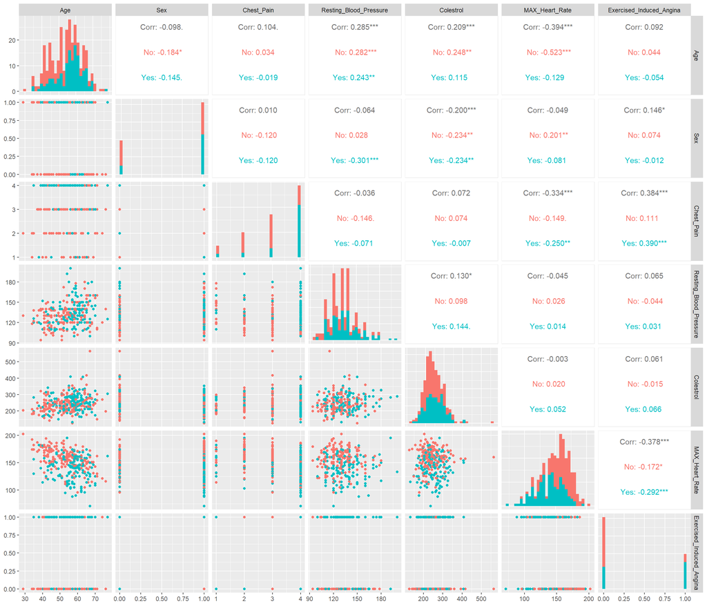

```r
ggpairs(heart_data, columns =
          c("Age", "Sex", "Chest_Pain", "Resting_Blood_Pressure", "Colestrol",
            "MAX_Heart_Rate", "Exercised_Induced_Angina"),
        ggplot2::aes(colour=heart_disease),
        diag = list(continuous="barDiag"))
```

# Logistic Regression: Prediction

- Split data into training and testing set (60:40 split)
- Fit logistic regression model on train, evaluate on test

```r
# Partition Data
set.seed(12)
train_test_indices <- createDataPartition(heart_data$heart_disease, p=0.6, list = FALSE)
heart_data_train <- heart_data[train_test_indices,]
heart_data_test <- heart_data[-train_test_indices,]

# Train
lm_fit <- glm(formula = heart_disease~Age+Sex+Chest_Pain+Resting_Blood_Pressure+Colestrol+
                MAX_Heart_Rate+Exercised_Induced_Angina,
              data = heart_data_train,
              family = binomial())

summary(lm_fit)
```

```
##
## Call:
## glm(formula = heart_disease ~ Age + Sex + Chest_Pain + Resting_Blood_Pressure +
##     Colestrol + MAX_Heart_Rate + Exercised_Induced_Angina, family = binomial(),
##     data = heart_data_train)
##
## Deviance Residuals:
##     Min       1Q   Median       3Q      Max
## -2.9043  -0.6570  -0.2297   0.5699   2.3395
##
## Coefficients:
##                           Estimate Std. Error z value Pr(>|z|)
## (Intercept)              -4.267477   2.897706  -1.473  0.14083
## Age                       0.004601   0.025999   0.177  0.85954
## Sex                       2.075197   0.532039   3.900 9.60e-05 ***
## Chest_Pain                0.588048   0.226267   2.599  0.00935 **
## Resting_Blood_Pressure    0.043279   0.013579   3.187  0.00144 **
## Colestrol                 0.006693   0.004119   1.625  0.10417
## MAX_Heart_Rate           -0.048617   0.012144  -4.004 6.24e-05 ***
## Exercised_Induced_Angina  1.552972   0.492859   3.151  0.00163 **
## ---
## Signif. codes:  0 '***' 0.001 '**' 0.01 '*' 0.05 '.' 0.1 ' ' 1
##
## (Dispersion parameter for binomial family taken to be 1)
##
##     Null deviance: 252.46  on 182  degrees of freedom
## Residual deviance: 152.29  on 175  degrees of freedom
## AIC: 168.29
##
## Number of Fisher Scoring iterations: 5
```

# Logistic Regression: Prediction

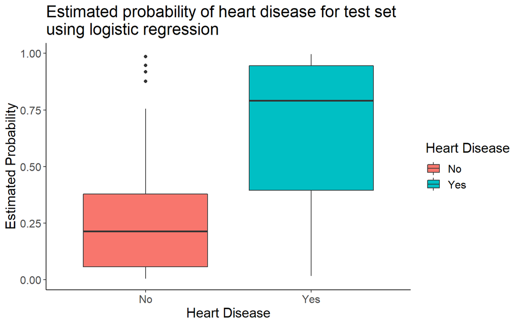

```r
# Add in test set predictions
heart_data_test$estimated_prob_heart_disease <-
  predict(lm_fit, newdata=heart_data_test, type = "response")

# View test set probabilities
ggplot(data=heart_data_test,
       mapping=aes(x=heart_disease, y=estimated_prob_heart_disease,
                   fill=heart_disease))+
  geom_boxplot()+
  labs(x="Heart Disease", y="Estimated Probability",
       title = "Estimated probability of heart disease for test set\nusing logistic regression",
       fill = "Heart Disease")+
  theme_classic()+
  theme(text = element_text(size=15))
```

# Logistic Regression: Prediction

- How to create predicted outcomes using estimated probabilities?
  - Easy way:

$$\begin{align}
\hat{Y_i} &= I[p(X_i)>0.5]\\
&=\begin{cases}
1 & \text{if } p(X_i)>0.5 \\
0 & \text{if } p(X_i)\leq0.5
\end{cases}
\end{align}$$

- In heart disease data:

```r
# Add in test set predictions
heart_data_test <-
  heart_data_test %>%
  mutate(pred_heart_disease =
           relevel(factor(ifelse(estimated_prob_heart_disease>0.5, "Yes", "No")),
                   ref = "No"))

# Compute confusion matrix
confusionMatrix(data = heart_data_test$pred_heart_disease,
                reference = heart_data_test$heart_disease,
                positive = "Yes")
```

```
## Confusion Matrix and Statistics
##
##           Reference
## Prediction No Yes
##        No  52  18
##        Yes 13  37
##
##                Accuracy : 0.7417
##                  95% CI : (0.6538, 0.8172)
##     No Information Rate : 0.5417
##     P-Value [Acc > NIR] : 5.135e-06
##
##                   Kappa : 0.4761
##
##  Mcnemar's Test P-Value : 0.4725
##
##             Sensitivity : 0.6727
##             Specificity : 0.8000
##          Pos Pred Value : 0.7400
##          Neg Pred Value : 0.7429
##              Prevalence : 0.4583
##          Detection Rate : 0.3083
##    Detection Prevalence : 0.4167
##       Balanced Accuracy : 0.7364
##
##        'Positive' Class : Yes
##
```

# Logistic Regression: Prediction

- What if we don’t split the data?

```r
# Add in train set predictions
heart_data_train$estimated_prob_heart_disease <-
  predict(lm_fit, newdata=heart_data_train, type = "response")

heart_data_train <-
  heart_data_train %>%
  mutate(pred_heart_disease =
           relevel(factor(ifelse(estimated_prob_heart_disease>0.5, "Yes", "No")),
                   ref = "No"))

# Compute confusion matrix
confusionMatrix(data = heart_data_train$pred_heart_disease,
                reference = heart_data_train$heart_disease,
                positive = "Yes")
```

```
## Confusion Matrix and Statistics
##
##           Reference
## Prediction No Yes
##        No  84  19
##        Yes 15  65
##
##                Accuracy : 0.8142
##                  95% CI : (0.7502, 0.8678)
##     No Information Rate : 0.541
##     P-Value [Acc > NIR] : 8.162e-15
##
##                   Kappa : 0.6245
##
##  Mcnemar's Test P-Value : 0.6069
##
##             Sensitivity : 0.7738
##             Specificity : 0.8485
##          Pos Pred Value : 0.8125
##          Neg Pred Value : 0.8155
##              Prevalence : 0.4590
##          Detection Rate : 0.3552
##    Detection Prevalence : 0.4372
##       Balanced Accuracy : 0.8111
##
##        'Positive' Class : Yes
##
```

- Not a big difference. **Why?**

# Classification: Threshold

- We defined $\hat{Y}$ using a 0.5 probability threshold
  - Other thresholds may give **better performance**
  - Infinitely many thresholds $\rightarrow$ how to aggregate?
  - Answer: *receiver operating characteristic* curve (ROC curve)

# ROC Curve

- For given threshold $p$, ROC curve is function:
  - $ROC(p) = (TPR, FPR)$
  - Maps each threshold to corresponding *true positive rate* (TPR) amd *false positive rate* pair
  - $TPR=\text{Sensitivity}$, $1-FPR=\text{Specificity}$
  - Helps choose “best” threshold based on sensitivity and specificity considerations

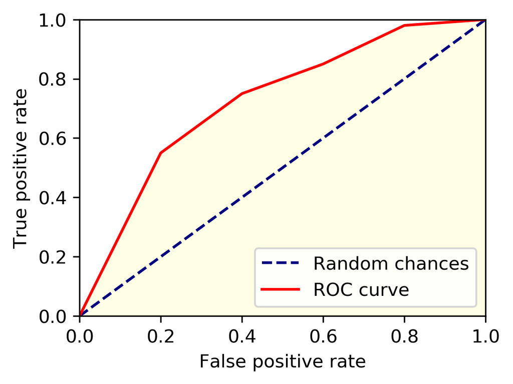

# ROC Curve Ex.

- Heart disease dataset example
- Let’s compute the ROC curve using the test set to evaluation differences thresholds

```r
# Using pROC, add ROC curve using estimated probabilities of heart disease in test set
roc_obj <-
  roc(response = heart_data_test$heart_disease,
    predictor = heart_data_test$estimated_prob_heart_disease)

# Print obj
roc_obj
```

```
##
## Call:
## roc.default(response = heart_data_test$heart_disease, predictor = heart_data_test$estimated_prob_heart_disease)
##
## Data: heart_data_test$estimated_prob_heart_disease in 65 controls (heart_data_test$heart_disease No) < 55 cases (heart_data_test$heart_disease Yes).
## Area under the curve: 0.8215
```

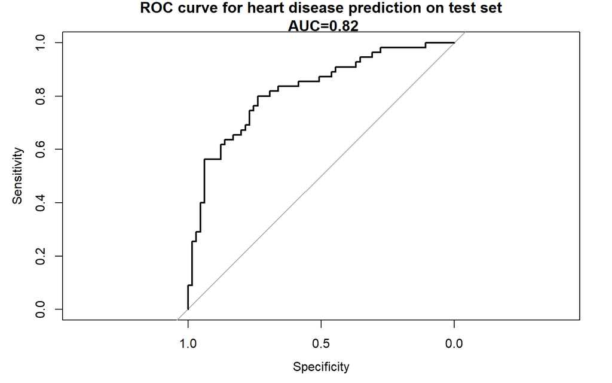

```r
# Plot curve
plot(roc_obj, main = paste0("ROC curve for heart disease prediction on test set\n AUC=",
                            round(auc(roc_obj),2)))
```

# ROC Curve Ex.

- For actual use, need to choose threshold
  - Example: “Elbow Point”/max(Youden’s Index)

```r
# Using pROC, add ROC curve using estimated probabilities of heart disease in test set
roc_obj <-
  roc(response = heart_data_test$heart_disease,
    predictor = heart_data_test$estimated_prob_heart_disease)

# Print obj
roc_obj
```

```
##
## Call:
## roc.default(response = heart_data_test$heart_disease, predictor = heart_data_test$estimated_prob_heart_disease)
##
## Data: heart_data_test$estimated_prob_heart_disease in 65 controls (heart_data_test$heart_disease No) < 55 cases (heart_data_test$heart_disease Yes).
## Area under the curve: 0.8215
```

```r
# Return max Youden's index, with specificity and sensitivity
best_thres_data <-
  data.frame(coords(roc_obj, x="best", best.method = c("youden", "closest.topleft")))

best_thres_data
```

```
##   threshold specificity sensitivity
## 1 0.3748977   0.7384615         0.8
```

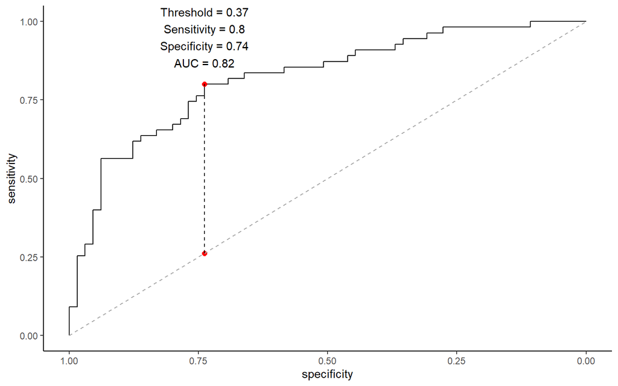

```r
# Plot curve, add in line at elbow point
data_add_line <-
  data.frame("sensitvity"=c(1-best_thres_data$specificity,
                            best_thres_data$sensitivity),
             "specificity"=c(best_thres_data$specificity,
                            best_thres_data$specificity))

ggroc(roc_obj)+
    geom_point(
    data = best_thres_data,
    mapping = aes(x=specificity, y=sensitivity), size=2, color="red")+
    geom_point(mapping=aes(x=best_thres_data$specificity,
               y=1-best_thres_data$specificity),
               size=2, color="red")+
    geom_segment(aes(x = 1, xend = 0, y = 0, yend = 1),
                 color="darkgrey", linetype="dashed")+
    geom_text(data = best_thres_data,
              mapping=aes(x=specificity, y=0.95,
                          label=paste0("Threshold = ", round(threshold,2),
                                       "\nSensitivity = ", round(sensitivity,2),
                                       "\nSpecificity = ", round(specificity,2),
                                       "\nAUC = ", round(auc(roc_obj),2))))+
    geom_line(data=data_add_line,
              mapping=aes(x=specificity, y=sensitvity),
              linetype="dashed")+
  theme_classic()
```

- Choose threshold based on study-specific **cost-benefit analysis**

# Case-control sampling

- 139 cases and 164 controls - $\hat{\pi}=$ 0.46
  - However, true proportion of heart disease in population is much lower ($\pi=0.05$)
- If model is correct, logistic regression allows accurate estimation of $\beta_j$, $j>0$
  - $\beta_0$ estimate **not** accruate due to baseline prevalance in sample
- Can **correct** intercept estimate using transformation:

$$\hat{\beta}^{*}_0=\hat{\beta_0}+\text{log}(\frac{\pi}{1-\pi})-\text{log}(\frac{\hat{\pi}}{1-\hat{\pi}})$$

- Case-control sampling done due to cases being rare
  - i.e., all cases in population selected
  - Controls then randomly sampled from population
  - How many controls to sample?

# Case-control sampling

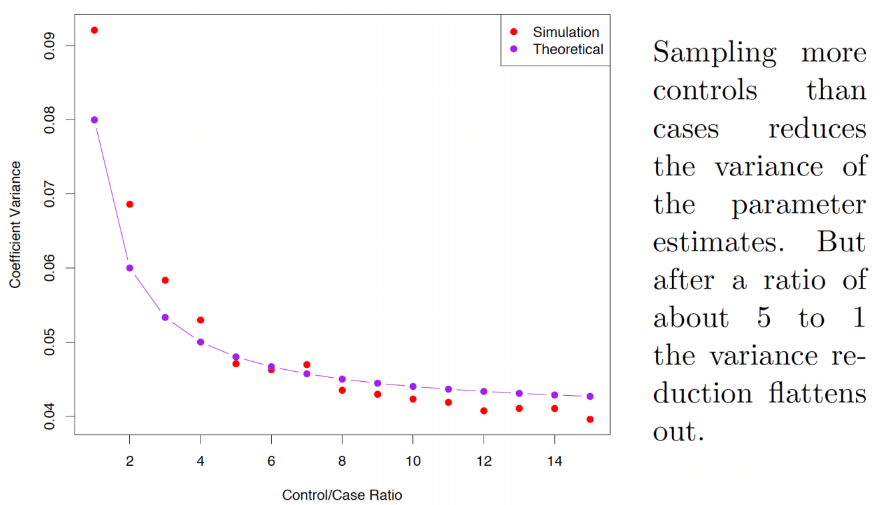

# Multi-class classification

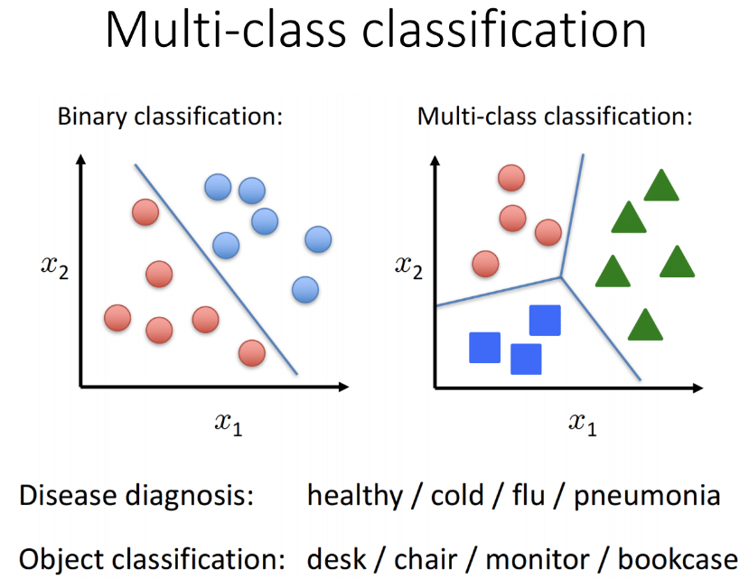

# Multi-class classification: logistic regression

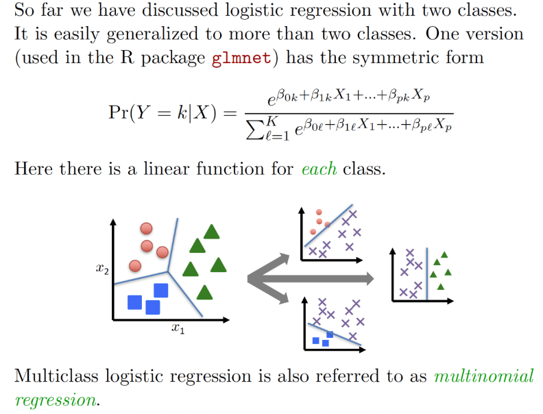

# Multi-class classification: logistic regression

- Can extend usual two-class logistic regression for multiple-classes
  - Don’t work well in practice
- Instead discuss other methods which are superior
  - Ex. Linear discrimminant analysis (LDA)